# Engagement en IG de Tenistas ATP

Datos: tenistas + posts + imágenes

Versión: 22-ago.-2024 13:37:19

```r
library(lmerTest)
library(ggplot2)
library(lattice)
library(ggpubr)       # 'ggplot2' Based Publication Ready Plots
library(moments)      # for computing skewness
library(sjPlot)
library(car)          # función: qqPlot, durbinWatsonTest, outlierTest
library(lmtest)       # función: bptest, gqtest
library(corrplot)
library(descr)
library(psych)
library(dplyr)        # funciones de dataframes
library(stargazer)
library(modelsummary)
library(broom)
library(kableExtra)
```

# Datos

## Carga de datos

```r
datos = read.csv("C:/Users/pvill/OneDrive/Documentos/TFG INTEGRADO/English_LIWC.csv")
```

Se han cargado 4676 filas y 88 columnas.

- Cambiamos el nombre a la variable de los instrumentos de tenis.
- Reordenamos las variables.
- Quitamos las filas que tengan -1 en los likes (hay 225).

```r
datos <- datos %>%
  rename(tennis.instruments = type) %>%
  select(-c(post, shortcode, Marcas.Jugador)) %>%
  relocate(likes:comentarios, .after = ID) %>%
  relocate(publicaciones:following, .after = username) %>%
  relocate(Puntos:Head, .after = username) %>%
  relocate(franja_horaria, .after = hora) %>%
  relocate(video, .after= hashtags ) %>%
  relocate(weekend, .after = fecha) %>%
  relocate(Australian_Open:US_Open, .after = weekend) %>%
  relocate(num_hashtags:idioma, .after = sponsors) %>%
  relocate(num_hashtags:word_count, .after = sponsors)

datos <- datos[datos$likes > 0, ]
```

Nos hemos quedado con **4451 filas** y 85 columnas. Las columnas del dataframe quedan del siguiente modo:

```r
colnames(datos)
```

```
##  [1] "ID"                 "likes"              "comentarios"
##  [4] "username"           "Puntos"             "Premio.monetario"
##  [7] "Edad"               "Nike"               "Wilson"
## [10] "Yonex"              "Adidas"             "Asics"
## [13] "Head"               "publicaciones"      "followers"
## [16] "following"          "fecha"              "weekend"
## [19] "Australian_Open"    "Roland_Garros"      "Wimbledon"
## [22] "US_Open"            "hora"               "franja_horaria"
## [25] "texto"              "hashtags"           "video"
## [28] "is_sponsored"       "sponsors"           "num_hashtags"
## [31] "num_mentions"       "num_emojis"         "idioma"
## [34] "texto.detectado"    "tennis.instruments" "rostros"
## [37] "emocion"            "word_count"         "Segment"
## [40] "WC"                 "Analytic"           "Clout"
## [43] "Authentic"          "Tone"               "Affect"
## [46] "tone_pos"           "tone_neg"           "emotion"
## [49] "emo_pos"            "emo_neg"            "emo_anx"
## [52] "emo_anger"          "emo_sad"            "swear"
## [55] "Social"             "socbehav"           "prosocial"
## [58] "polite"             "conflict"           "moral"
## [61] "comm"               "socrefs"            "family"
## [64] "friend"             "female"             "male"
## [67] "Culture"            "politic"            "ethnicity"
## [70] "tech"               "Lifestyle"          "leisure"
## [73] "home"               "work"               "money"
## [76] "relig"              "Physical"           "health"
## [79] "illness"            "wellness"           "mental"
## [82] "substances"         "sexual"             "food"
## [85] "death"
```

## Preprocesamiento

- Cambiamos Puntos de texto a número.
- En la Edad, tenemos 1 celdas vacías. Las vamos a llenar con la edad media.
- En texto.detectado y tennis.instruments, pasamos del string a 1/0.
- Establecemos la emoción neutra como referencia.
- Ordenamos las categorías de franja_horaria.

```r
# PUNTOS
datos$Puntos <- gsub(",", "", datos$Puntos)
datos$Puntos <- as.numeric(datos$Puntos)
# EDAD
datos$Edad[is.na(datos$Edad)] <- mean(datos$Edad, na.rm = TRUE)
# TRANSFORMACIÓN DE texto.detectado
datos$texto.detectado <- ifelse(datos$texto.detectado == "SÍ", 1, 0)
# TRANSFORMACIÓN DE tennis.instruments
datos$tennis.instruments <- ifelse(datos$tennis.instruments == "with tennis instruments", 1, 0)
# REFERENCIA DE emocion
datos$emocion <- factor(datos$emocion, levels = c('neutral', 'happy', 'surprise', 'fear', 'disgust', 'angry', 'sad'))

# ORDENACIÓN DE franja_horaria
datos$franja_horaria <- factor(datos$franja_horaria, levels = c('Mañana', 'Tarde', 'Noche'))
```

## Exploración de las variables categóricas

Se presentan a continuación los diagramas de caja y bigotes de las variables categóricas sobre los likes y los comentarios. Puesto que estas dos variables tienen una gran dispersión, se han excluido de los diagramas los valores que están más allá de los bigotes, es decir, sin los valores atípicos.

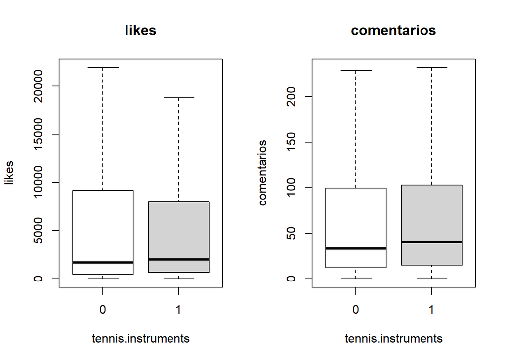

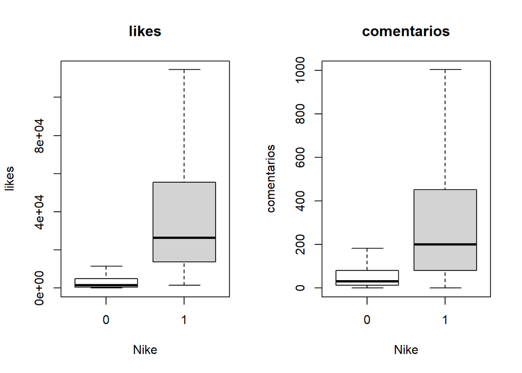

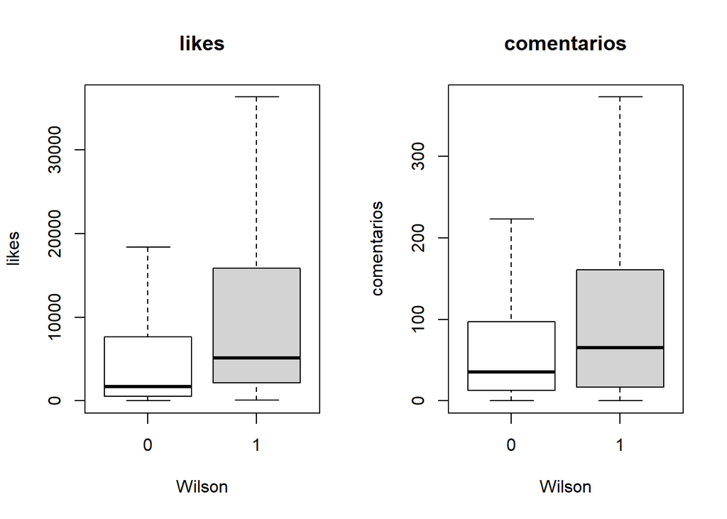

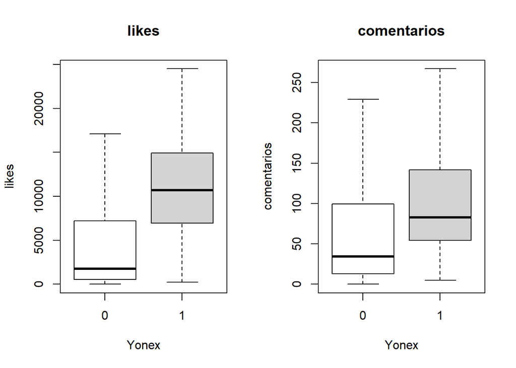

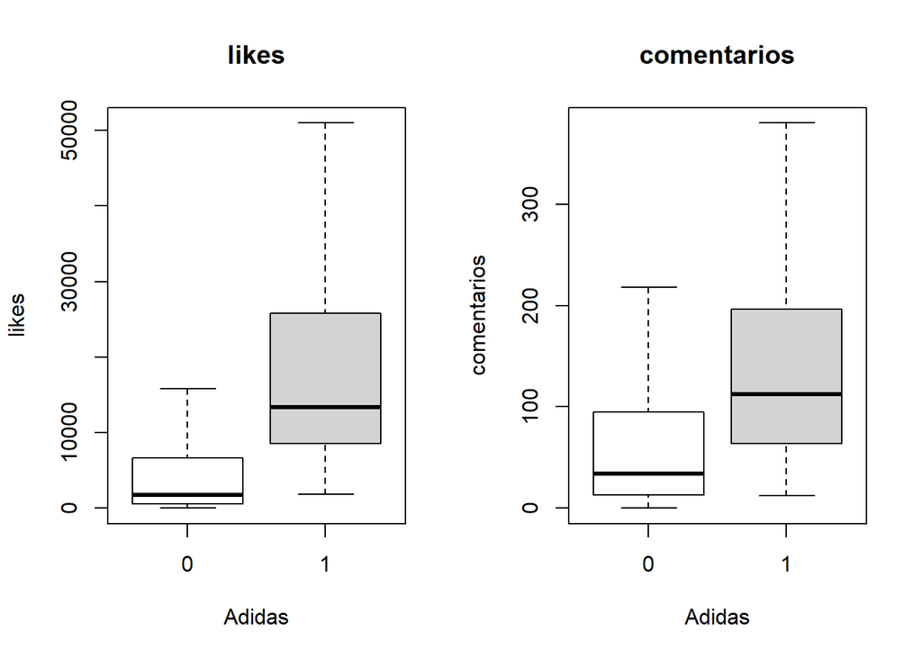

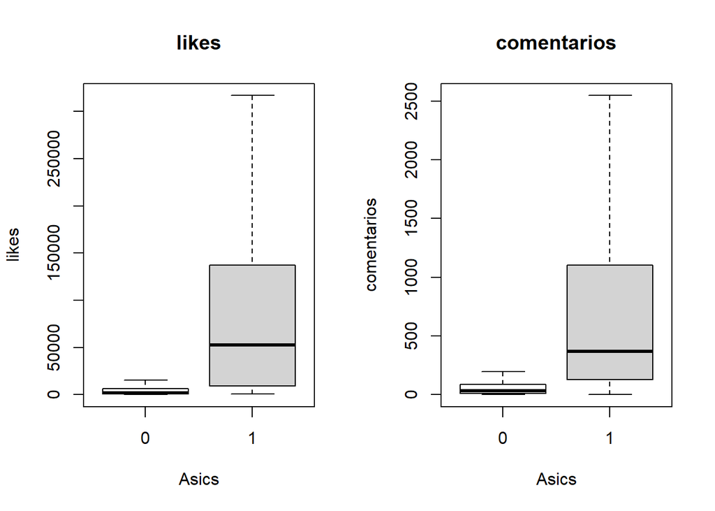

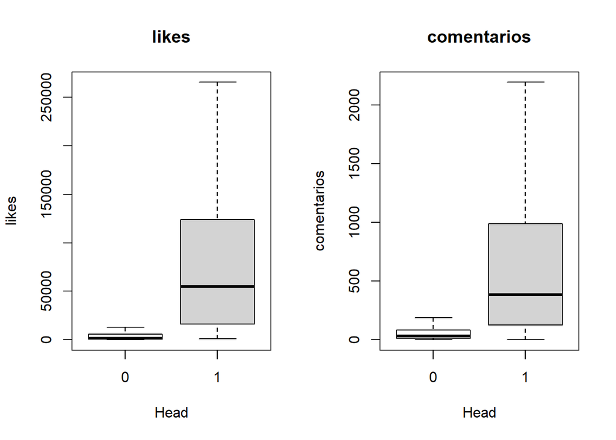

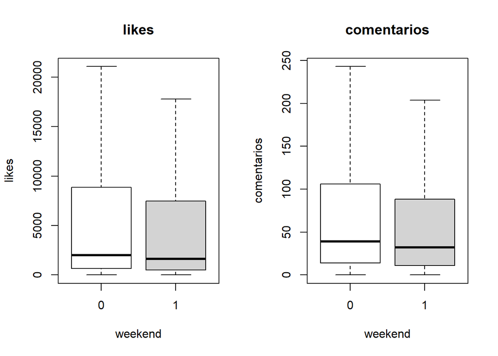

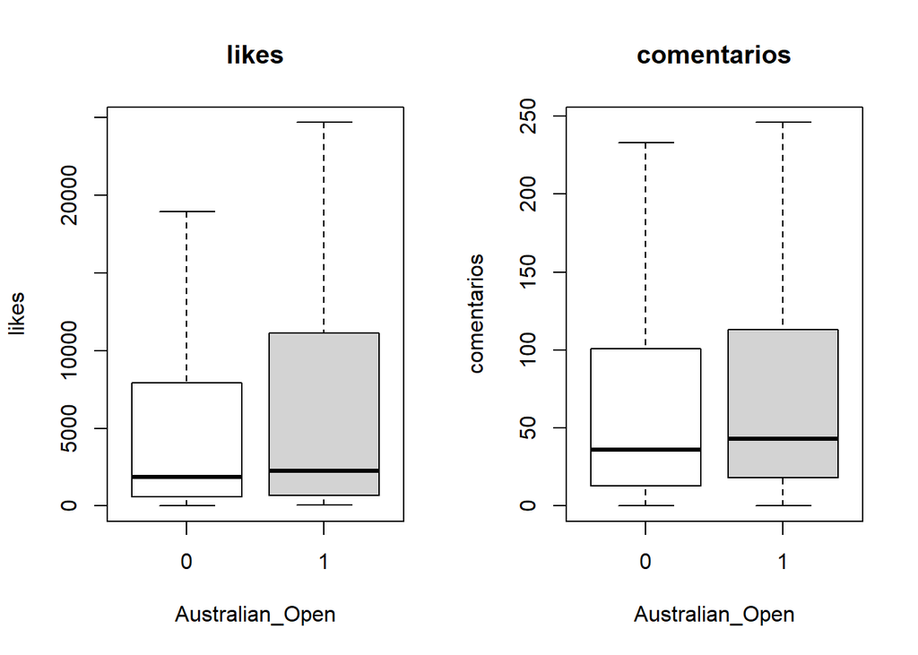

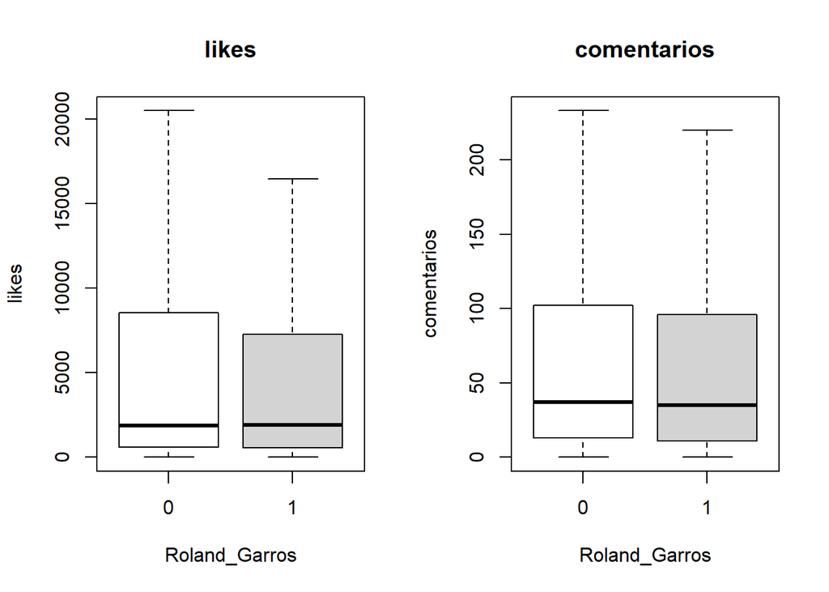

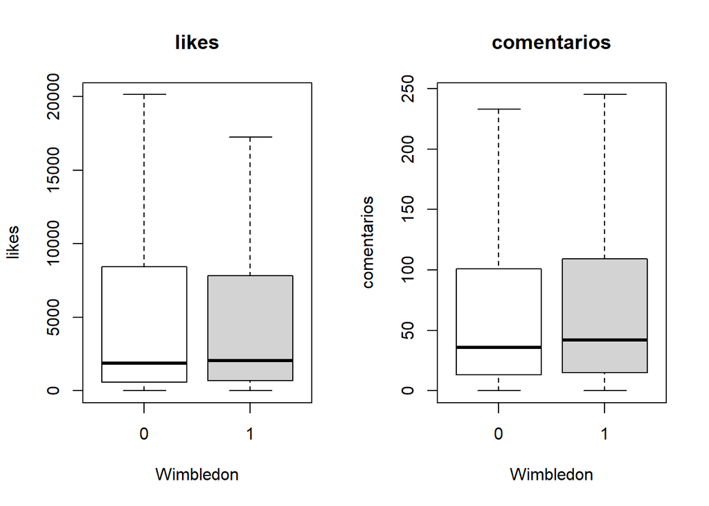

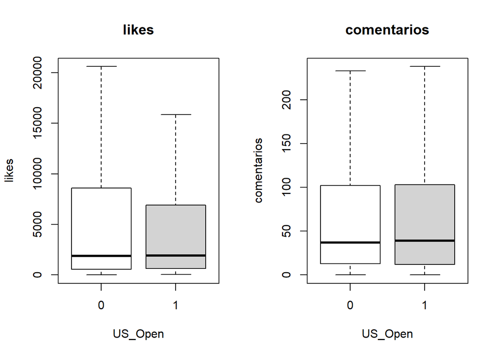

[2 more figures not shown]

```r
par(mfrow = c(1, 2))

lista_variables <- c('tennis.instruments', 'Nike', "Wilson", "Yonex", "Adidas", "Asics", "Head", "weekend", "Australian_Open", "Roland_Garros", "Wimbledon", "US_Open", 'texto.detectado', 'video')

for (variable in lista_variables){
  boxplot(likes ~ (eval(parse(text = variable))), col=c("white","lightgray"), datos, main = 'likes', xlab = variable, outline = FALSE)
  boxplot(comentarios ~ (eval(parse(text = variable))), col=c("white","lightgray"), datos, main = 'comentarios', xlab = variable, outline = FALSE)
}
```

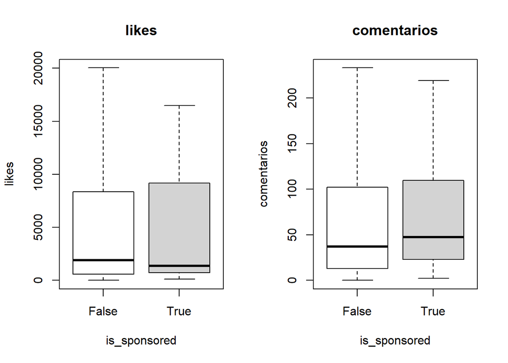

```r
boxplot(likes ~ is_sponsored, col=c("white","lightgray","darkgray"), datos, main = 'likes', outline = FALSE)
boxplot(comentarios ~ is_sponsored, col=c("white","lightgray","darkgray"), datos, main = 'comentarios', outline = FALSE)
```

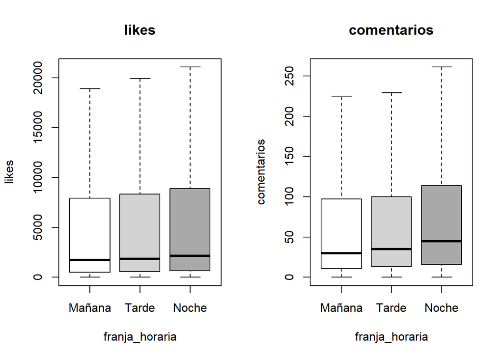

```r
boxplot(likes ~ franja_horaria, col=c("white","lightgray","darkgray"), datos, main = 'likes', outline = FALSE)
boxplot(comentarios ~ franja_horaria, col=c("white","lightgray","darkgray"), datos, main = 'comentarios', outline = FALSE)
```

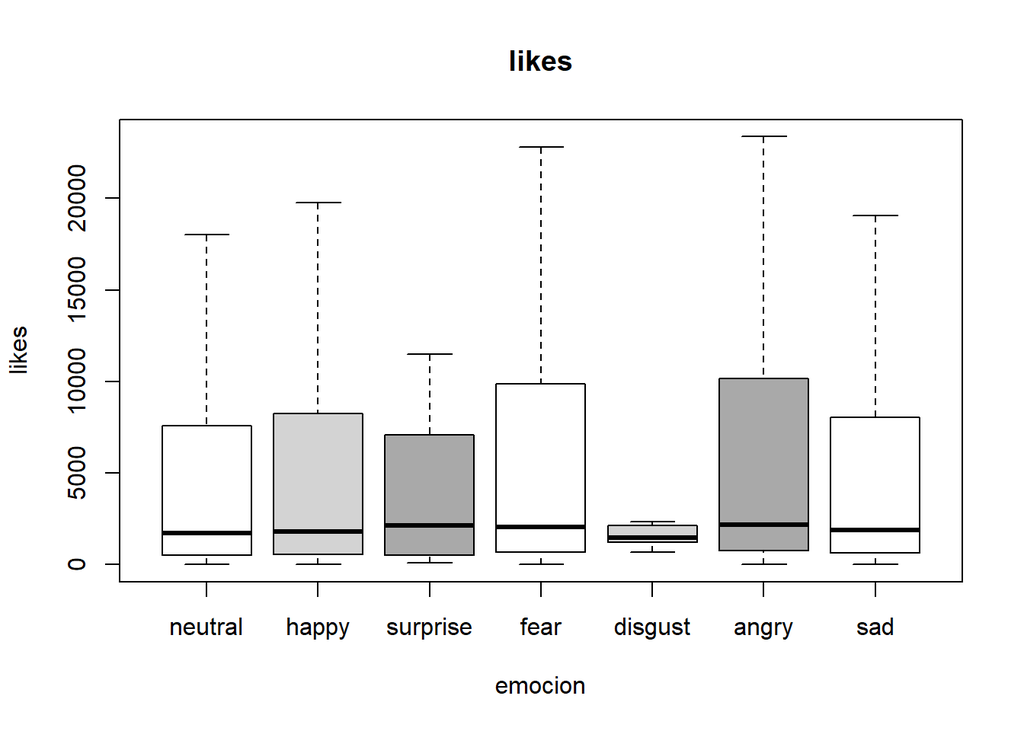

```r
boxplot(likes ~ emocion, col=c("white","lightgray","darkgray"), datos, main = 'likes', outline = FALSE)
```

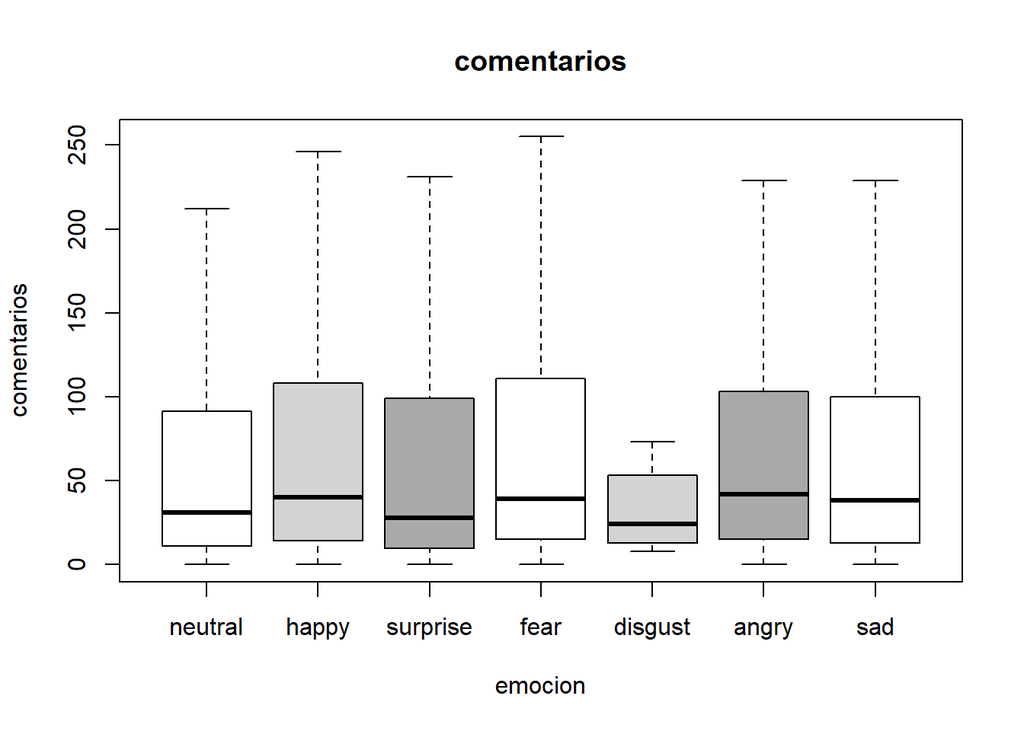

```r
boxplot(comentarios ~ emocion, col=c("white","lightgray","darkgray"), datos, main = 'comentarios', outline = FALSE)
```

## Preprocesamiento de las variables continuas

### Estadísticas Descriptivas

```r
lista <- c("idioma" , "Segment","WC", "Analytic", "Clout", "Authentic", "Tone", "Affect", "emotion", "emo_anx", "emo_anger", "emo_sad", "swear", "Social", "socbehav", "conflict", "moral", "comm", "socrefs", "family", "friend", "female", "male", "Culture", "politic",  "ethnicity", "tech", "leisure", "home", "work", "money", "relig", "Physical", "illness", "wellness", "mental", "substances", "sexual", "food", "death")

datos <- select(datos, -all_of(lista))

x <- describe(select(datos, -ID), ranges = TRUE, omit = TRUE) %>%
  select(-c(trimmed, mad, range, se))
knitr::kable(x, digits = 3)
```

|  | vars | n | mean | sd | median | min | max | skew | kurtosis |
| --- | --- | --- | --- | --- | --- | --- | --- | --- | --- |
| likes | 1 | 4451 | 16208.283 | 63603.622 | 1895.00 | 10 | 1941286.00 | 14.596 | 336.819 |
| comentarios | 2 | 4451 | 172.615 | 793.294 | 37.00 | 0 | 30777.00 | 21.252 | 667.453 |
| Puntos | 4 | 4451 | 1052.651 | 1841.133 | 538.00 | 1 | 9855.00 | 3.671 | 13.765 |
| Premio.monetario | 5 | 4451 | 150184.489 | 288109.807 | 82155.00 | 0 | 2105775.00 | 4.552 | 24.988 |
| Edad | 6 | 4451 | 26.832 | 5.016 | 26.00 | 16 | 45.00 | 0.623 | 0.069 |
| Nike | 7 | 4451 | 0.093 | 0.291 | 0.00 | 0 | 1.00 | 2.792 | 5.799 |
| Wilson | 8 | 4451 | 0.070 | 0.255 | 0.00 | 0 | 1.00 | 3.367 | 9.336 |
| Yonex | 9 | 4451 | 0.036 | 0.186 | 0.00 | 0 | 1.00 | 5.001 | 23.019 |
| Adidas | 10 | 4451 | 0.042 | 0.200 | 0.00 | 0 | 1.00 | 4.578 | 18.964 |
| Asics | 11 | 4451 | 0.052 | 0.222 | 0.00 | 0 | 1.00 | 4.039 | 14.315 |
| Head | 12 | 4451 | 0.077 | 0.266 | 0.00 | 0 | 1.00 | 3.177 | 8.093 |
| publicaciones | 13 | 4451 | 408.503 | 374.092 | 289.00 | 3 | 1980.00 | 1.688 | 3.057 |
| followers | 14 | 4451 | 8226368.721 | 35853369.212 | 499.00 | 10 | 212000000.00 | 4.681 | 20.988 |
| following | 15 | 4451 | 705.451 | 607.057 | 646.00 | 0 | 4829.00 | 4.143 | 24.617 |
| weekend | 17 | 4451 | 0.301 | 0.459 | 0.00 | 0 | 1.00 | 0.867 | -1.248 |
| Australian_Open | 18 | 4451 | 0.110 | 0.313 | 0.00 | 0 | 1.00 | 2.494 | 4.222 |
| Roland_Garros | 19 | 4451 | 0.097 | 0.296 | 0.00 | 0 | 1.00 | 2.717 | 5.383 |
| Wimbledon | 20 | 4451 | 0.114 | 0.317 | 0.00 | 0 | 1.00 | 2.433 | 3.922 |
| US_Open | 21 | 4451 | 0.115 | 0.320 | 0.00 | 0 | 1.00 | 2.405 | 3.787 |
| video | 26 | 4451 | 0.279 | 0.448 | 0.00 | 0 | 1.00 | 0.986 | -1.028 |
| num_hashtags | 29 | 4451 | 1.995 | 4.062 | 0.00 | 0 | 30.00 | 3.948 | 20.081 |
| num_mentions | 30 | 4451 | 1.149 | 1.439 | 1.00 | 0 | 24.00 | 3.265 | 24.621 |
| num_emojis | 31 | 4451 | 2.200 | 2.052 | 2.00 | 0 | 27.00 | 2.230 | 11.380 |
| texto.detectado | 32 | 4451 | 0.235 | 0.424 | 0.00 | 0 | 1.00 | 1.250 | -0.439 |
| tennis.instruments | 33 | 4451 | 0.569 | 0.495 | 1.00 | 0 | 1.00 | -0.277 | -1.924 |
| rostros | 34 | 4451 | 2.708 | 6.222 | 1.00 | 0 | 116.00 | 8.411 | 97.849 |
| word_count | 36 | 4451 | 22.990 | 31.954 | 15.00 | 1 | 440.00 | 5.737 | 49.194 |
| tone_pos | 37 | 4451 | 7.265 | 9.006 | 5.26 | 0 | 100.00 | 2.389 | 11.962 |
| tone_neg | 38 | 4451 | 0.617 | 2.499 | 0.00 | 0 | 33.33 | 6.833 | 62.390 |
| emo_pos | 39 | 4451 | 2.233 | 5.231 | 0.00 | 0 | 100.00 | 4.950 | 45.874 |
| emo_neg | 40 | 4451 | 0.104 | 0.884 | 0.00 | 0 | 25.00 | 14.811 | 292.993 |
| prosocial | 41 | 4451 | 1.789 | 4.263 | 0.00 | 0 | 50.00 | 3.938 | 23.284 |
| polite | 42 | 4451 | 1.082 | 3.672 | 0.00 | 0 | 100.00 | 9.446 | 167.752 |
| Lifestyle | 43 | 4451 | 5.708 | 9.443 | 0.00 | 0 | 100.00 | 3.140 | 16.551 |
| health | 44 | 4451 | 0.295 | 1.916 | 0.00 | 0 | 33.33 | 10.403 | 128.085 |

Teniendo en cuenta que “As a general guideline, a skewness value between −1 and +1 is considered excellent, but a value between −2 and +2 is generally considered acceptable. Values beyond −2 and +2 are considered indicative of substantial nonnormality.” (Hair et al., 2022, p. 66)“, vamos a tener que tratar algunas variables, especialmente likes, comentarios, Premio.monetario, los followers, los following y los rostros.

### Matriz de Correlaciones entre las variables continuas

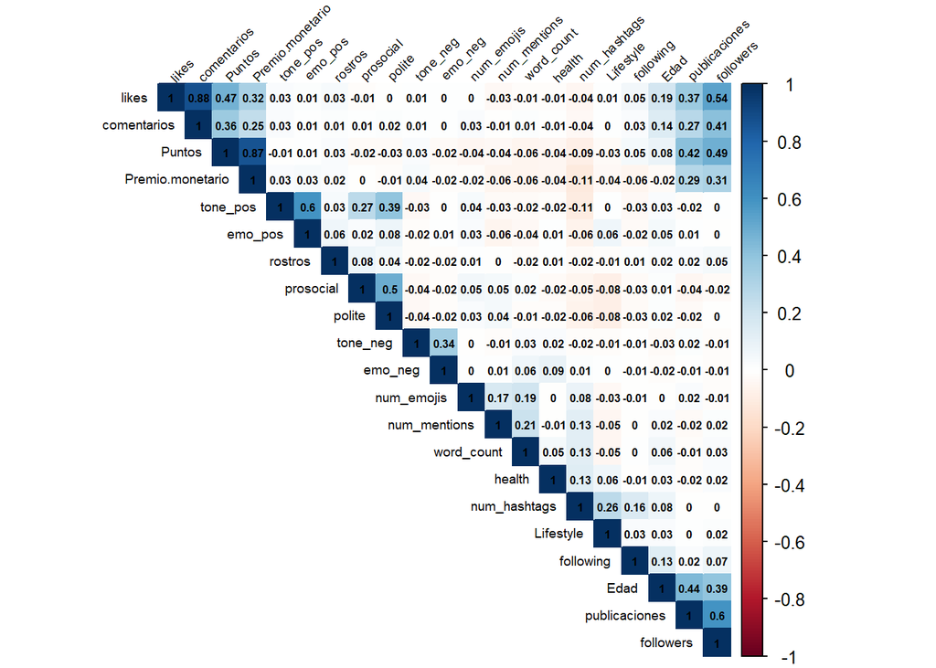

```r
lista_variables_continuas <- c('likes', 'comentarios', "Puntos","Premio.monetario", "Edad", "publicaciones","followers", "following", "num_hashtags","num_mentions", "num_emojis", "word_count", 'rostros', "tone_pos", "tone_neg", "emo_pos", "emo_neg", "prosocial", "polite", "Lifestyle", "health")
#corrplot(cor(select(datos, all_of(lista_variables_continuas))), method = "color", type = "upper", order = "hclust", addCoef.col = "black", tl.col = "black", tl.srt = 45)
#matrix <- cor(select(datos, all_of(lista_variables_continuas)))
cor_matrix <- cor(select(datos, all_of(lista_variables_continuas)))

# Ajustar el tamaño de la ventana gráfica
par(cex.main=0.8, cex.lab=0.8, cex.axis=0.7, mar=c(0, 0, 0, 0) + 0.5)

# Ajustar los parámetros del gráfico
corrplot(cor_matrix,
         method = "color",
         type = "upper",
         order = "hclust",
         addCoef.col = "black",
         tl.col = "black",
         tl.srt = 45,
         tl.cex = 0.6,  # Tamaño de las etiquetas
         cl.cex = 0.8,  # Tamaño de la leyenda
         number.cex = 0.5)  # Tamaño de los coeficientes
```

### LIWC

Al añadir las nuevas variables de LIWC, podemos destacar 4 variables: tone_pos/emo_pos, prosocial/polite. No están altamente correlacionadas, encontramos un valor de 0.6 y 0.5, respectivamente.

### Exploración de las variables continuas

Vamos a probar dos transformaciones: la raíz cuadrada y la logarítmica. Para estas transformadas, y también para el original, evaluamos la skewness.

```r
lista_variables = c('likes', 'comentarios', 'Puntos', 'Edad', 'publicaciones', 'followers', 'following', 'num_hashtags', 'num_mentions', 'num_emojis', 'rostros', 'word_count',"tone_pos", "tone_neg", "emo_pos", "emo_neg", "prosocial", "polite", "Lifestyle", "health")

for (variable in lista_variables){
  cat(paste0('\n\n#### ', variable, '\n\n'))

  variable.sqrt = paste0(variable, '.sqrt')
  variable.log = paste0(variable, '.log')

  # hacemos los cálculos de las transformadas
  datos[[variable.sqrt]] <- sqrt(datos[[variable]])
  if (any(grepl(0, datos[[variable]]))){
    x <- datos[[variable]]
    x <- replace(x, x==0, 1)
    datos[[variable.log]] <- log(x)
  }else{
    datos[[variable.log]] <- log(datos[[variable]])
  }

  # dibujamos las tres figuras
  print(ggplot(datos, aes(x=eval(parse(text = variable)))) + geom_density() + stat_overlay_normal_density(color = "red", linetype = "dashed") + labs(title = "En Bruto", x=variable))
  print(ggplot(datos, aes(x=eval(parse(text = variable.sqrt)))) + geom_density() + stat_overlay_normal_density(color = "red", linetype = "dashed") + labs(title = "Transformada: Raíz Cuadrada", x=variable.sqrt))
  print(ggplot(datos, aes(x=eval(parse(text = variable.log)))) + geom_density() + stat_overlay_normal_density(color = "red", linetype = "dashed") + labs(title = "Transformada: Logaritmo", x=variable.log))

  # evaluamos la skewness
  skew.raw <- skewness(datos[[variable]], na.rm = TRUE)
  skew.sqrt <- skewness(datos[[variable.sqrt]], na.rm = TRUE)
  skew.log <- skewness(datos[[variable.log]], na.rm = TRUE)

  df.resultados <- data.frame(
    original.skewness = skew.raw,
    raiz.skewness = skew.sqrt,
    log.skewness = skew.log
  )

  print(knitr::kable(df.resultados,
                     caption = paste0('Resultados de los test de skewness para la variable ', variable, '.')))
}
```

#### likes

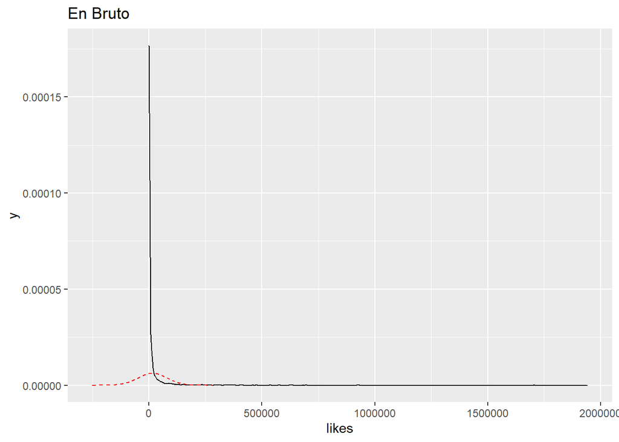

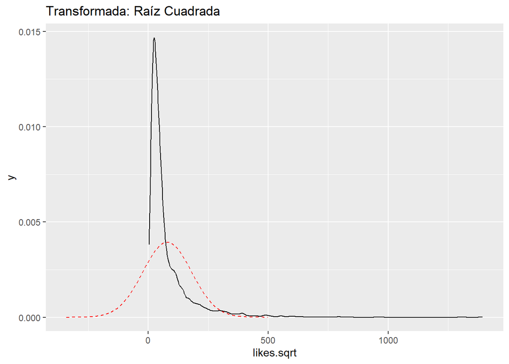

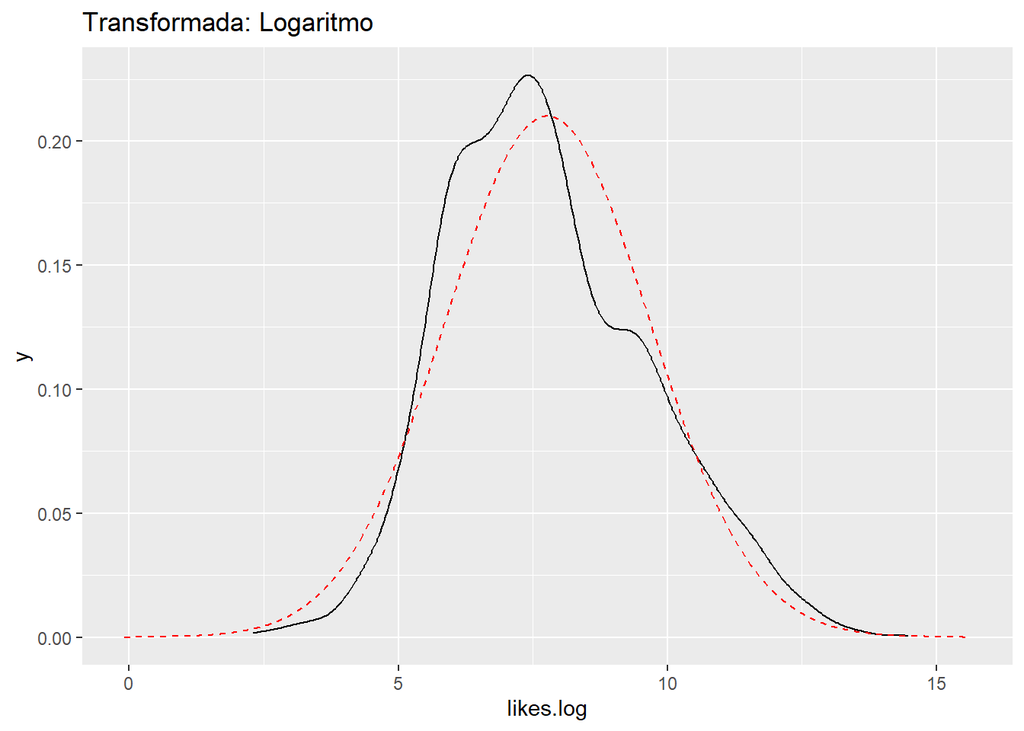

Resultados de los test de skewness para la variable likes.

| original.skewness | raiz.skewness | log.skewness |
| --- | --- | --- |
| 14.60082 | 3.818859 | 0.4066963 |

#### comentarios

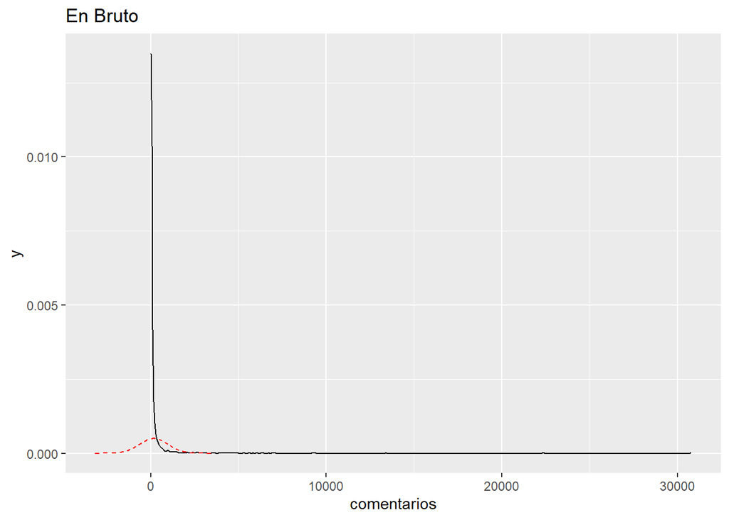

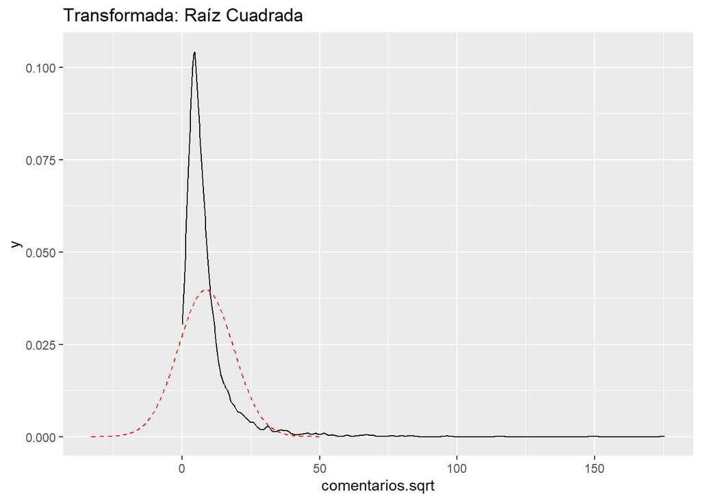

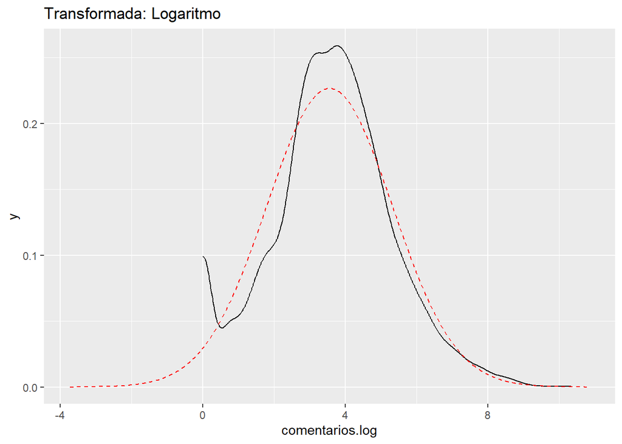

Resultados de los test de skewness para la variable comentarios.

| original.skewness | raiz.skewness | log.skewness |
| --- | --- | --- |
| 21.2594 | 4.848891 | 0.0027433 |

#### Puntos

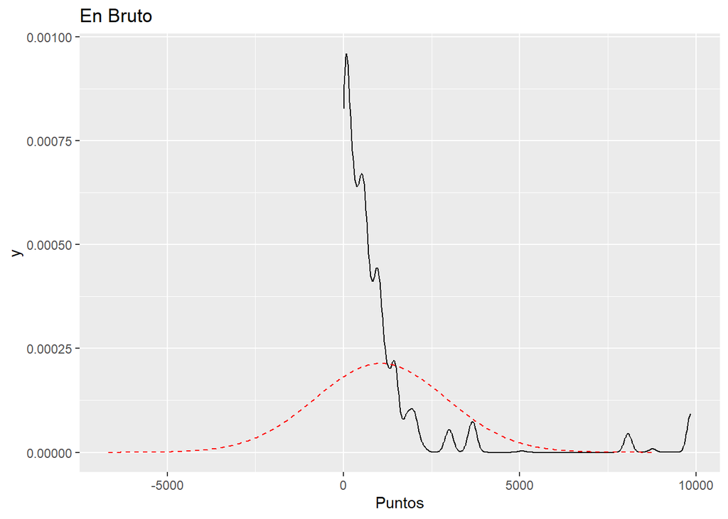

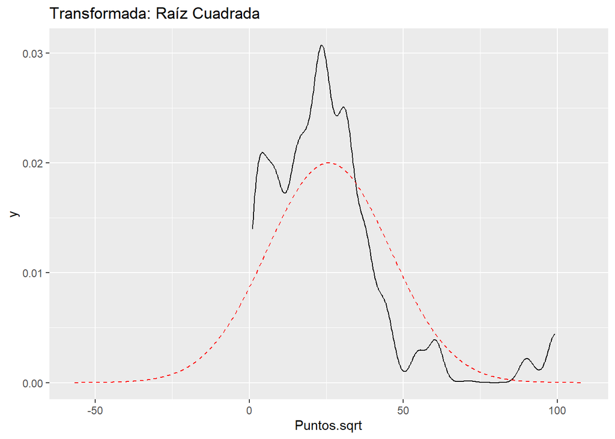

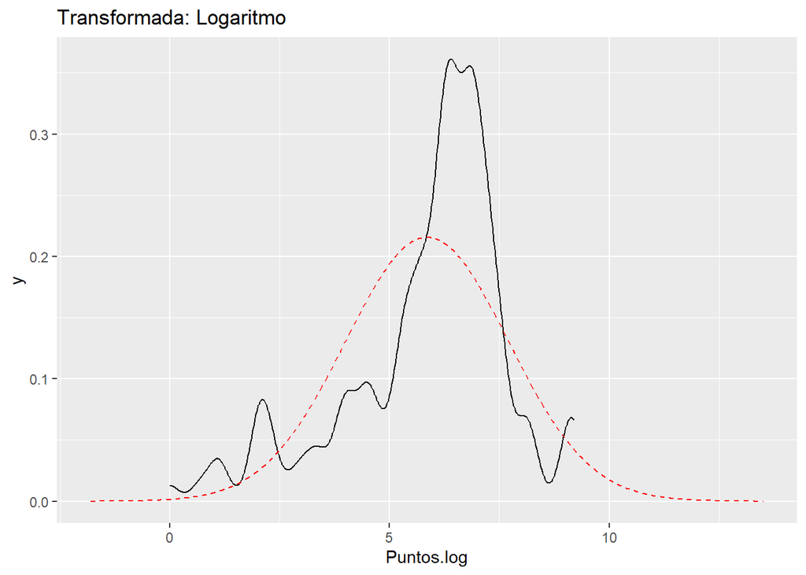

Resultados de los test de skewness para la variable Puntos.

| original.skewness | raiz.skewness | log.skewness |
| --- | --- | --- |
| 3.672506 | 1.798729 | -0.9586948 |

#### Edad

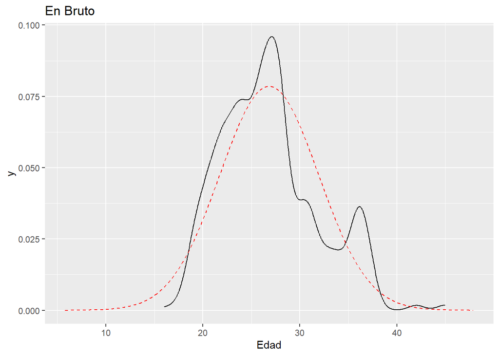

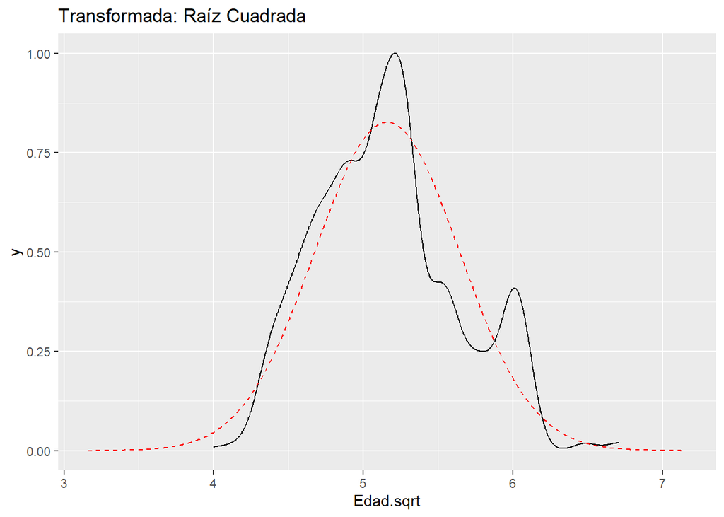

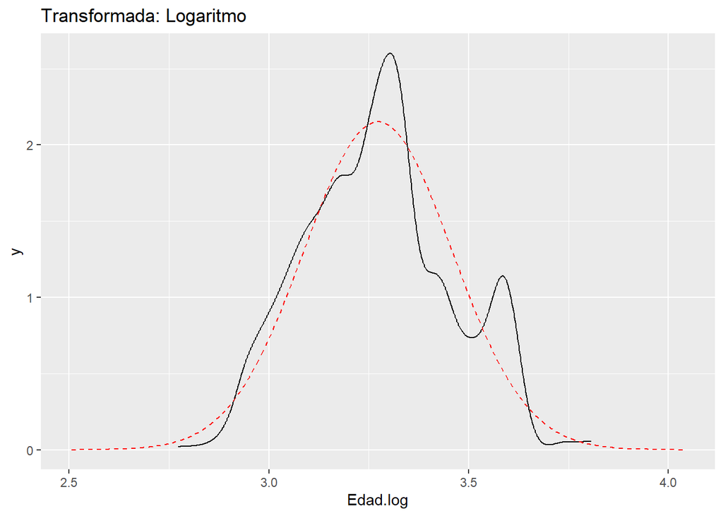

Resultados de los test de skewness para la variable Edad.

| original.skewness | raiz.skewness | log.skewness |
| --- | --- | --- |
| 0.6232932 | 0.4048981 | 0.1910356 |

#### publicaciones

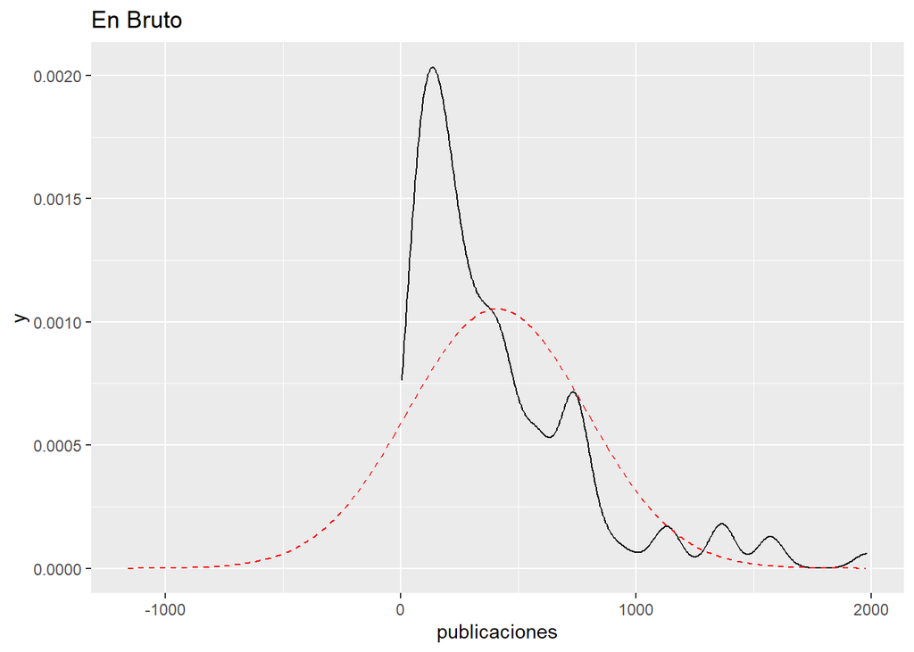

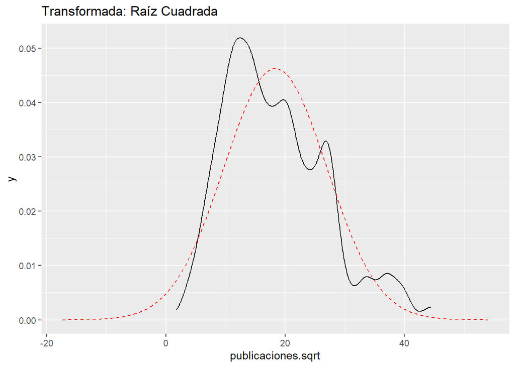

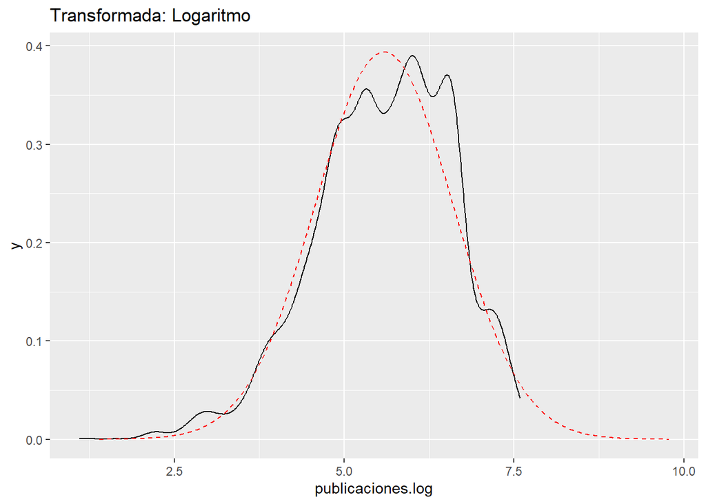

Resultados de los test de skewness para la variable publicaciones.

| original.skewness | raiz.skewness | log.skewness |
| --- | --- | --- |
| 1.688143 | 0.6956732 | -0.4834797 |